# Efficient Bayesian generalized linear models with time-varying coefficients

Jouni Helske

15 May 2020

## Introduction

More specifically, the linear model with time-varying coefficients is defined as
$$\begin{aligned}
y_t &= x'_t \beta_t + \epsilon_t, \quad t = 1,\ldots, n\\
\beta_{t+1} &= \beta_t + \eta_t,
\end{aligned}$$
where $y_t$ is the observation at time $t$, $x_t$ contains the corresponding predictor variables, $\beta_t$ is a $k$ dimensional vector of regression coefficients at time $t$, $\epsilon_t \sim N(0, \sigma^2_{\epsilon})$, and $\eta_t \sim N(0, D)$, with $D$ being $k \times k$ diagonal matrix with diagonal elements $\sigma^2_{i,\eta}$, $i=1,\ldots,k$. Denote the unknown parameters of the model by $\beta = (\beta'_1, \ldots, \beta'_n)'$ and $\sigma = (\sigma_{\epsilon}, \sigma_{1, \eta}, \ldots, \sigma_{k, \eta})$. We define priors for first $\beta_1$ as $N(\mu_{\beta_1}, \sigma_{\beta_1})$, and for $\sigma_i \sim N(\mu_{\sigma_i}, \sigma_{\sigma_i})$, $i=1,\ldots,k+1$, truncated to positive values.

Although in principle writing this model as above in `Stan` is straightforward, standard implementation can lead to some computational problems (see the illustration in next Section). An alternative solution used by `walker` is based on the marginalization of the regression coefficients $\beta$ during the MCMC sampling by using the Kalman filter. This provides fast and accurate inference of marginal posterior $p(\sigma | y)$. Then, the corresponding joint posterior $p(\sigma, \beta | y) = p(\beta | \sigma, y)p(\sigma | y)$ can be obtained by simulating the regression coefficients given marginal posterior of standard deviations. This sampling can be performed for example by simulation smoothing algorithm by Durbin and Koopman (2002). Note that we have opted to sample the $\beta$ parameters given $\sigma$’s, but it is also possible to obtain somewhat more accurate summary statistics such as mean and variance of these parameters by using the standard Kalman smoother for computation of $\textrm{E}(\beta| \sigma, y)$ and $\textrm{Var}(\beta| \sigma, y)$, and using the law of total expectation.

In this vignette we first introduce the basic use using simple linear regression model with first order random walk, and then discuss extensions to second order random walk, as well as how to deal with non-Gaussian data.

## Illustration

Let us consider a observations $y$ of length $n=100$, generated by random walk (i.e. time varying intercept) and two predictors. This is rather small problem, but it was chosen in order to make possible comparisons with the “naive” `Stan` implementation. For larger problems (in terms of number of observations and especially number of predictors) it is very difficult to get naive implementation to work properly, as even after tweaking several parameters of the underlying MCMC sampler, one typically ends up with divergent transitions or low BMFI index, meaning that the results are not to be trusted.

First we simulate the coefficients and the predictors:

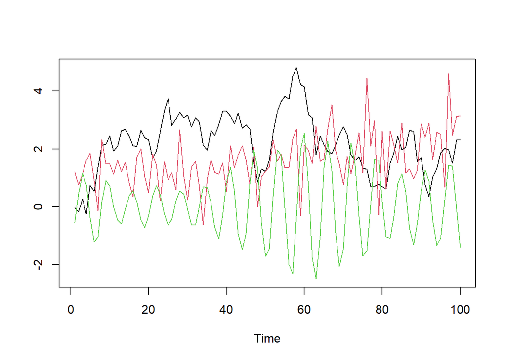

```r
set.seed(1)
n <- 100
beta1 <- cumsum(c(0.5, rnorm(n - 1, 0, sd = 0.05)))
beta2 <- cumsum(c(-1, rnorm(n - 1, 0, sd = 0.15)))
x1 <- rnorm(n, mean = 2)
x2 <- cos(1:n)
rw <- cumsum(rnorm(n, 0, 0.5))
ts.plot(cbind(rw, beta1 * x1, beta2 * x2), col = 1:3)
```

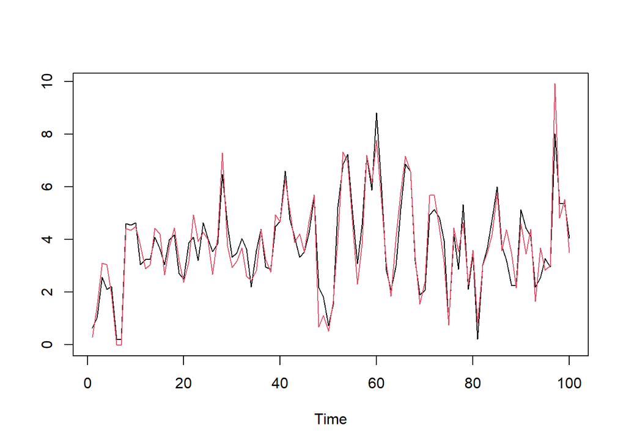

```r
signal <- rw + beta1 * x1 + beta2 * x2
y <- rnorm(n, signal, 0.5)
ts.plot(cbind(signal, y), col = 1:2)
```

Then we can call function `walker`. The model is defined as a formula like in `lm`, and we can give several arguments which are passed to `sampling` method of `rstan`, such as number of iteration `iter` and number of chains `chains` (default values for these are 2000 and 4). In addition to these, we use arguments `beta` and `sigma`, which define the prior distributions for $\beta_1$ and $\sigma$ respectively. These arguments should length two vectors, where the first value defines the prior mean, and the second value defines the prior standard deviation.

```r
fit <- walker(y ~ -1 + rw1(~ x1 + x2, beta = c(0, 10), sigma = c(0, 10)),
  refresh = 0, chains = 2, sigma_y = c(0, 10), seed = 1)
```

We sometimes get a few (typically one) warning message about numerical problems, as the sampling algorithm warms up, but this is nothing to be concerned with (if more errors occur, then a Github issue for `walker` package is more than welcome).

The output of `walker` is `walker_fit` object, which is essentially a list with `stanfit` from `Stan`’s `sampling` function, and the original observations `y` and the covariate matrix `xreg`. Thus we can use all the ready made tools for postprocessing `stanfit` objects:

```r
print(fit$stanfit, pars = c("sigma_y", "sigma_rw1"))
```

```
## Inference for Stan model: walker_lm.
## 2 chains, each with iter=2000; warmup=1000; thin=1;
## post-warmup draws per chain=1000, total post-warmup draws=2000.
##
##              mean se_mean   sd 2.5%  25%  50%  75% 97.5% n_eff Rhat
## sigma_y      0.49    0.01 0.16 0.07 0.41 0.51 0.59  0.75   402    1
## sigma_rw1[1] 0.60    0.01 0.14 0.36 0.51 0.59 0.69  0.90   594    1
## sigma_rw1[2] 0.08    0.00 0.04 0.01 0.05 0.08 0.10  0.17  1009    1
## sigma_rw1[3] 0.32    0.00 0.10 0.15 0.24 0.31 0.38  0.57  1267    1
##
## Samples were drawn using NUTS(diag_e) at Fri May 15 17:18:16 2020.
## For each parameter, n_eff is a crude measure of effective sample size,
## and Rhat is the potential scale reduction factor on split chains (at
## convergence, Rhat=1).
```

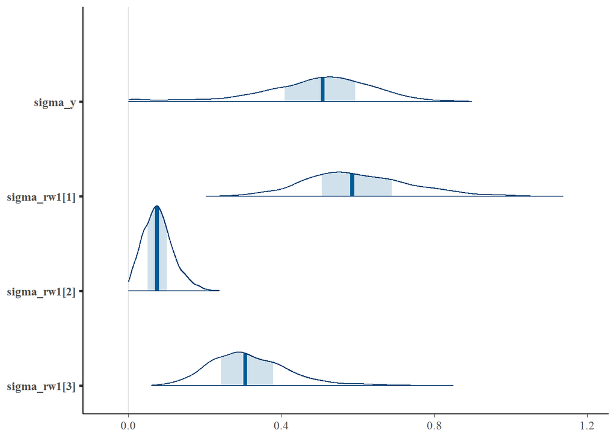

```r
library(bayesplot)
mcmc_areas(as.matrix(fit$stanfit), regex_pars = c("sigma_y", "sigma_rw1"))
```

Let’s check how well our estimates of $\beta$ coincide with the true values (the solid lines correspond to true values):

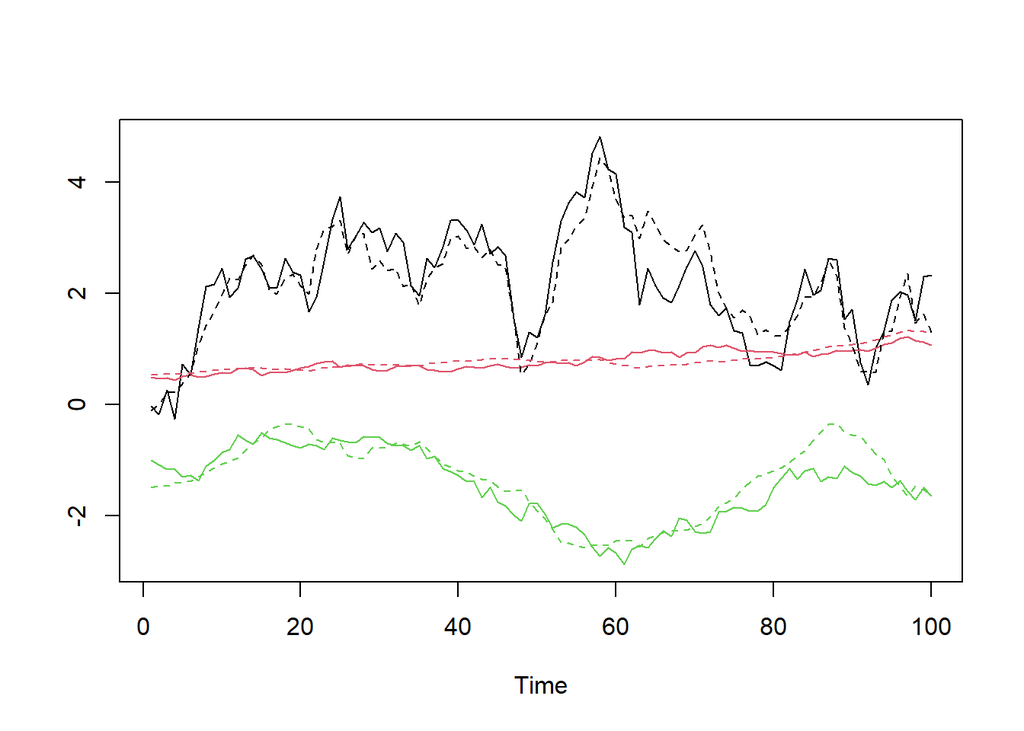

```r
betas <- summary(fit$stanfit, "beta_rw")$summary[, "mean"]

ts.plot(cbind(rw, beta1, beta2, matrix(betas, ncol = 3)),
  col = rep(1:3, 2), lty = rep(1:2, each = 3))
```

There is also simpler (and prettier) `ggplot` based plotting function for coefficients:

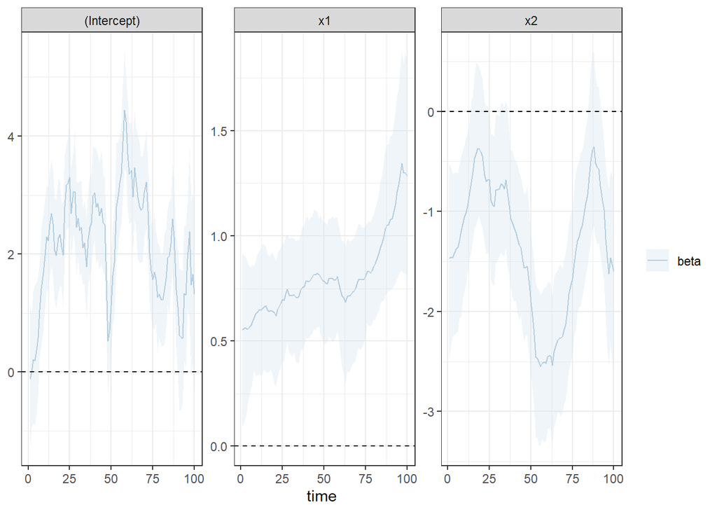

```r
plot_coefs(fit, scales = "free") + theme_bw()
```

### Posterior predictive checks

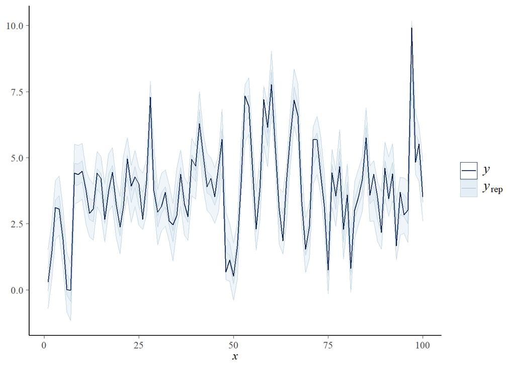

```r
pp_check(fit)
```

### Out-of-sample prediction

It is also possible to obtain actual forecasts given new covariates $x^{new}$:

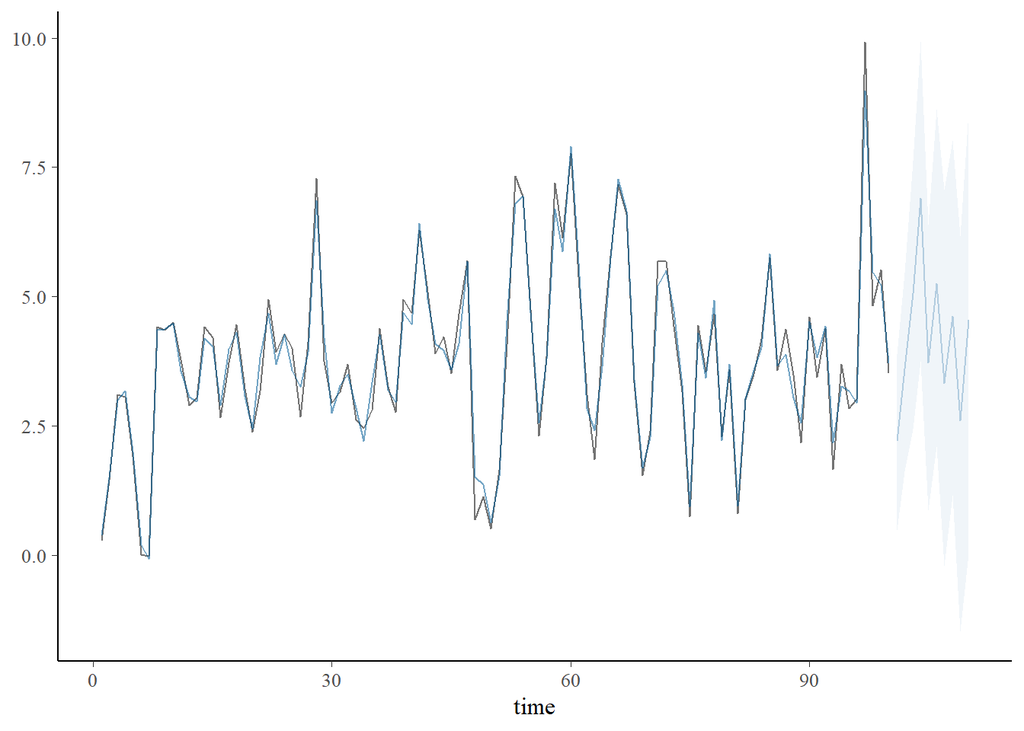

```r
new_data <- data.frame(x1 = rnorm(10, mean = 2), x2 = cos((n + 1):(n + 10)))
pred <- predict(fit, new_data)
plot_predict(pred)
```

## Extensions: Smoother effects and non-Gaussian models

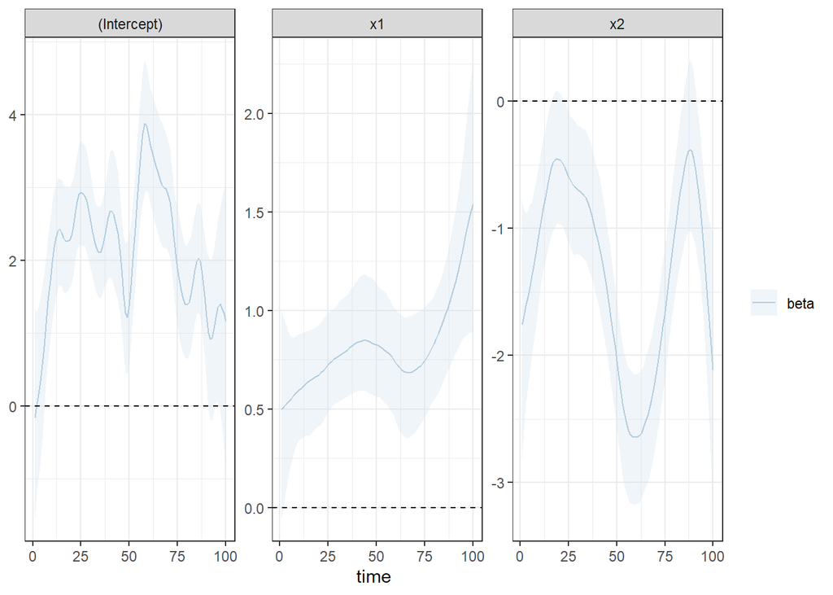

```r
fit_rw2 <-walker(y ~ -1 +
    rw2(~ x1 + x2, beta = c(0, 10), sigma = c(0, 10), nu = c(0, 10)),
  refresh = 0, chains = 2, sigma_y = c(0, 10))
plot_coefs(fit_rw2, scales = "free") + theme_bw()
```

So far we have focused on simple Gaussian linear regression. The above treatment cannot be directly extended to non-Gaussian models such as Poisson regression, as the marginal log-likelihood is intractable. However, it is possible to use relatively accurate Gaussian approximations, and the resulting approximate posterior can then be weighted using importance sampling type correction (Vihola, Helske, and Franks 2017), leading to exact inference. Function `walker_glm` extends the the package to handle Poisson and binomial observations using the aforementioned methodology.

## Comparison with naive approach

We now compare the efficiency of the “naive” implementation and the state space approach. For this, we use function `walker_rw1`, which supports only basic random walk models. We can perform the same analysis with naive implementation by setting the argument `naive` to `TRUE`:

```r
naive_fit <- walker_rw1(y ~ x1 + x2, seed = 1, refresh = 0, chains = 2,
  beta = cbind(0, rep(5, 3)), sigma = cbind(0, rep(2, 4)),
  naive = TRUE, control = list(adapt_delta = 0.95, max_treedepth = 15))
```

Let’s run the state space version again:

```r
kalman_fit <- walker_rw1(y ~ x1 + x2, seed = 1, refresh = 0, chains = 2,
   beta = cbind(0, rep(5, 3)), sigma = cbind(0, rep(2, 4)),
   naive = FALSE)
```

```r
print(naive_fit$stanfit, pars = c("sigma_y", "sigma_b"))
```

```
## Inference for Stan model: rw1_model_naive.
## 2 chains, each with iter=2000; warmup=1000; thin=1;
## post-warmup draws per chain=1000, total post-warmup draws=2000.
##
##            mean se_mean   sd 2.5%  25%  50%  75% 97.5% n_eff Rhat
## sigma_y    0.51    0.01 0.12 0.23 0.44 0.51 0.59  0.74    71 1.03
## sigma_b[1] 0.58    0.01 0.11 0.36 0.50 0.58 0.66  0.81   145 1.01
## sigma_b[2] 0.08    0.00 0.04 0.01 0.05 0.08 0.10  0.17   436 1.01
## sigma_b[3] 0.32    0.01 0.11 0.15 0.25 0.31 0.38  0.56   250 1.01
##
## Samples were drawn using NUTS(diag_e) at Fri May 15 17:21:03 2020.
## For each parameter, n_eff is a crude measure of effective sample size,
## and Rhat is the potential scale reduction factor on split chains (at
## convergence, Rhat=1).
```

```r
print(kalman_fit$stanfit, pars = c("sigma_y", "sigma_b"))
```

```
## Inference for Stan model: rw1_model.
## 2 chains, each with iter=2000; warmup=1000; thin=1;
## post-warmup draws per chain=1000, total post-warmup draws=2000.
##
##            mean se_mean   sd 2.5%  25%  50%  75% 97.5% n_eff Rhat
## sigma_y    0.49    0.01 0.14 0.16 0.41 0.50 0.58  0.72   577    1
## sigma_b[1] 0.60    0.00 0.13 0.38 0.51 0.59 0.69  0.89   748    1
## sigma_b[2] 0.08    0.00 0.04 0.01 0.05 0.07 0.10  0.16   976    1
## sigma_b[3] 0.31    0.00 0.10 0.15 0.25 0.30 0.37  0.53  1481    1
##
## Samples were drawn using NUTS(diag_e) at Fri May 15 17:21:20 2020.
## For each parameter, n_eff is a crude measure of effective sample size,
## and Rhat is the potential scale reduction factor on split chains (at
## convergence, Rhat=1).
```

```r
sum(get_elapsed_time(naive_fit$stanfit))
```

```
## [1] 129.485
```

```r
sum(get_elapsed_time(kalman_fit$stanfit))
```

```
## [1] 15.315
```

With naive implementation we get smaller effective sample sizes and much higher computation time, as well as some indications of divergence problems, even with adjusted step size (argument `adapt_delta`).

## Discussion

In this vignette we illustrated the benefits of marginalisation in the context of time-varying regression models. The underlying idea is not new; this approach is typical in classic Metropolis-type algorithms for linear-Gaussian state space models where the marginal likelihood $p(y | \theta)$ (where $\theta$ denotes the hyperparameters i.e. not the latents states such as $\beta$’s in current context) is used in the computation of the acceptance probability. Here we rely on readily available Hamiltonian Monte Carlo based `Stan` software, thus allowing us to enjoy the benefits of diverse tools of the `Stan` community.

The motivation behind the `walker` was to test the efficiency of importance sampling type weighting method of Vihola, Helske, and Franks (2017) in a dynamic generalized linear model setting within the HMC context. Although some of our other preliminary results have suggested that naive combination of the HMC with IS weighting can provide rather limited computational gains, in case of dynamic GLMs so called global approximation technique (Vihola, Helske, and Franks 2017) provides fast and robust alternative to standard HMC approach of `Stan`.

## Acknowledgements

This work has been supported by the Academy of Finland research grants 284513, 312605, and 311877.

## References

Durbin, J., and S. J. Koopman. 2002. “A Simple and Efficient Simulation Smoother for State Space Time Series Analysis.” *Biometrika* 89: 603–15.

Harvey, A. C. 1989. *Forecasting, Structural Time Series Models and the Kalman Filter*. Cambridge University Press.

R Core Team. 2017. *R: A Language and Environment for Statistical Computing*. Vienna, Austria: R Foundation for Statistical Computing. https://www.R-project.org/.

Stan Development Team. 2016a. *RStan: The R Interface to Stan*. http://mc-stan.org/.

———. 2016b. *The Stan C++ Library*. http://mc-stan.org/.

———. 2017. *Shinystan: Interactive Visual and Numerical Diagnostics and Posterior Analysis for Bayesian Models.* http://mc-stan.org/.

Vihola, M., J. Helske, and J. Franks. 2017. “Importance sampling type estimators based on approximate marginal MCMC.” *ArXiv E-Prints*, September. https://arxiv.org/abs/1609.02541.